# week06_hwa

## 5조 (6인 같은 5인조)

### - 팀 주 제 : 노인 일자리 정책 현황과 개선 방안

### - 개인 주제 : 국내 노인 일자리 정책 분석 (발표자: 곽성화)

### ※ DataBase

[figure not shown]

```python
# 모듈 로딩
import pymysql                     # SQL의 DB 사용
import pandas as pd                # DataFrame 저장 및 사용
# import requests                  # 한글 깨짐 문제를 방지
# from collections import Counter
import matplotlib.pyplot as plt    # 그래프로 시각화
# import time
# import re
import platform                    # 한글 깨짐 문제를 방지
import warnings                    # 경고창 무시
warnings.filterwarnings(action='ignore')

# 한글 깨지는 문제 해결하기 위해 운영체제별 font_path 지정
if platform.system() == 'Windows':   # Windows
    path = r'c:\Windows\Fonts\malgun.ttf'
elif platform.system() == 'Darwin':  # Mac OS
    path = r'/System/Library/Fonts/AppleGothic'
else:                                # Linux
    path = r'/usr/share/fonts/truetype/name/NanumMyeongjo.ttf'

# Matplotlib 한글 Font 설정
from matplotlib import font_manager as fm, rc
font_path='../Fonts/malgun.ttf'
font_name=fm.FontProperties(fname=font_path).get_name()
rc('font',family=font_name)

plt.rcParams['font.size']=15    # 글자크기
plt.rcParams['axes.unicode_minus']=False    # 마이너스 기호 깨지는 현상을 해결
```

```python
# mysql 데이터 조회 함수
def sql_select(sql):
    conn = pymysql.connect(host='localhost', user='root', password='0000', db = 'team_project', charset='utf8')  # DB 접속
    curs = conn.cursor()       # 커서 생성
    curs.execute(sql)          # sql문 실행
    rows = curs.fetchall()     # 모든 데이터를 가져옴
    curs.close()               # 커서 종료
    conn.close()               # MySQL 연결 종료
    return rows
```

### 1-1. 연도별 노인일자리 지원사업 창출실적

```python
# 조회 sql문 작성
sql="""
select year, result from senior_job_service;
"""

# sql문 조회 결과 -> DF 생성
people_df = pd.DataFrame(sql_select(sql), columns=['year', 'result'])

# 연도를 인덱스로 설정
people_df2=people_df.set_index(people_df['year'])
# people_df2
```

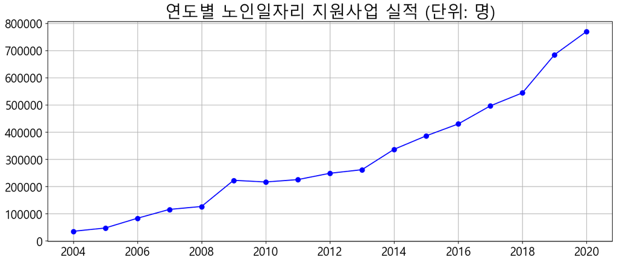

```python
# 그래프로 시각화
plt.figure(dpi=100, figsize=(15,6))
plt.plot(people_df2['year'], people_df2['result'], 'bo-', ms = 7)
plt.title('연도별 노인일자리 지원사업 실적 (단위: 명)', fontdict={'fontsize': 25})
plt.xticks(size=17)
plt.yticks(size=17)
plt.grid(True)   # 격자
plt.show()
```

```python
a=people_df2['result']
print(f'노인일자리 지원사업 실적 평균 => {round(a.mean()):,}명')
print(f'노인일자리 지원사업 실적 최대 시점 => {a.idxmax()}년, {round(a.max()):,}명')
print(f'노인일자리 지원사업 실적 최소 시점 => {a.idxmin()}년, {round(a.min()):,}명')
print(f'{a.idxmax()}년 노인일자리 지원사업 실적은 {a.idxmin()}년 대비 {round(a.max()/a.min())}배 상승')
# 2010년 대비 3.5배 상승, 2004년 대비 22배 상승
```

```
노인일자리 지원사업 실적 평균 => 307,514명
노인일자리 지원사업 실적 최대 시점 => 2020년, 769,605명
노인일자리 지원사업 실적 최소 시점 => 2004년, 35,127명
2020년 노인일자리 지원사업 실적은 2004년 대비 22배 상승
```

### 1-2. 연도별 노인일자리 지원사업 예산

```python
# 조회 sql문 작성
sql="""
select year, budget from senior_job_service;
"""

# sql문 조회 결과 -> DF 생성
budget_df = pd.DataFrame(sql_select(sql), columns=['year', 'budget'])

# 연도를 인덱스로 설정
budget_df2=budget_df.set_index(budget_df['year'])
# budget_df2
```

```python
# 예산 단위 '백만원' => '억'으로 환산
budget_df2['budget2']=budget_df2['budget']/100
# budget_df
```

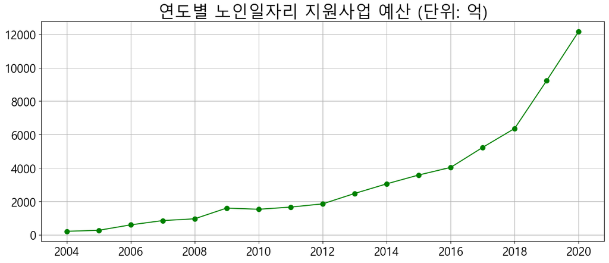

```python
# 그래프로 시각화
plt.figure(dpi=100, figsize=(15,6))
plt.plot(budget_df2['year'], budget_df2['budget2'], 'go-', ms = 7)
plt.title('연도별 노인일자리 지원사업 예산 (단위: 억)', fontdict={'fontsize': 25})
plt.xticks(size=17)
plt.yticks(size=17)
plt.grid(True)   # 격자
plt.show()
```

```python
a=budget_df2['budget2']
print(f'노인일자리 지원사업 예산 평균 => {round(a.mean()):,}억원')
print(f'노인일자리 지원사업 예산 최대 시점 => {a.idxmax()}년, {round(a.max()):,}억원')
print(f'노인일자리 지원사업 예산 최소 시점 => {a.idxmin()}년, {round(a.min()):,}억원')
print(f'{a.idxmax()}년 노인일자리 지원사업 예산은 {a.idxmin()}년 대비 {round(a.max()/a.min())}배 상승')
# 2010년 대비 8배 상승, 2004년 대비 57배 상승
```

```
노인일자리 지원사업 예산 평균 => 3,276억원
노인일자리 지원사업 예산 최대 시점 => 2020년, 12,168억원
노인일자리 지원사업 예산 최소 시점 => 2004년, 213억원
2020년 노인일자리 지원사업 예산은 2004년 대비 57배 상승
```

### 1-3. 연도별 노인일자리 지원사업 실적과 예산 간의 상관성

```python
# DF 합치기
senior_job = pd.merge(people_df, budget_df)

# 연도를 인덱스로 설정
senior_job=senior_job.set_index(senior_job['year'])
# senior_job

# 데이터 정규화
senior_job_normal = (senior_job - senior_job.mean())/senior_job.std()
# senior_job_normal
```

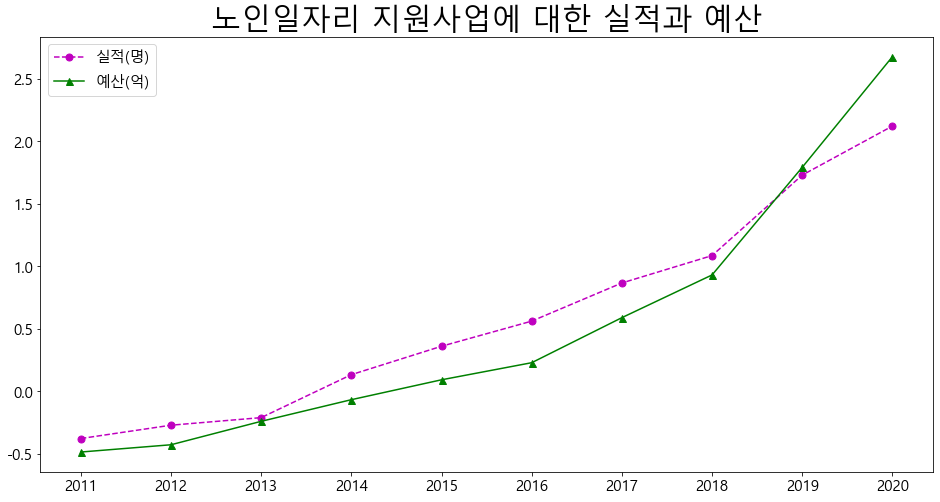

```python
# 그래프에 사용하기 위해 dataframe에서 list 추출
people_list = senior_job_normal['result'].to_list()[7:]
budget_list = senior_job_normal['budget'].to_list()[7:]

year = pd.date_range(start='2011', end='2021', freq='Y').strftime('%Y').to_list()

# 그래프로 시각화
plt.figure(figsize=(16,8))
plt.plot(year, people_list, 'mo--', label='실적(명)', ms = 7)
plt.legend()    # 범례
plt.plot(year, budget_list, 'g^-', label='예산(억)', ms = 7)
plt.legend()    # 범례
# plt.xlabel('2021년 월별')    # x축 라벨
plt.title('노인일자리 지원사업에 대한 실적과 예산', fontdict={'fontsize': 30})
plt.xticks(year)

plt.show()
```

```python
# 노인일자리 지원사업에 대한 실적과 예산 간의 상관관계
senior_job_corr=senior_job.corr()
print(f'노인일자리 지원사업에 대한 실적과 예산 간의 상관관계 => {senior_job_corr.iloc[1][2]}')
```

```
노인일자리 지원사업에 대한 실적과 예산 간의 상관관계 => 0.9693192339756379
```

### [결과 해석]

노인일자리 지원사업의 실적과 예산은 **지속적으로 증가하는 추세**  
상관계수 : 0.97 => **강한 양의 상관관계**

### 2-1. 2020년 노인일자리 지원사업 유형별 실적

```python
# 조회 sql문 작성
sql="""
select type1, type2, type3, type4, type5, type6, type7, type8, type9
    from senior_job_service
where year=2020;
"""

# sql문 조회 결과 -> DF 생성
service_df = pd.DataFrame(sql_select(sql)).T
# service_df
# service_df[0].sort_values(ascending=False)
```

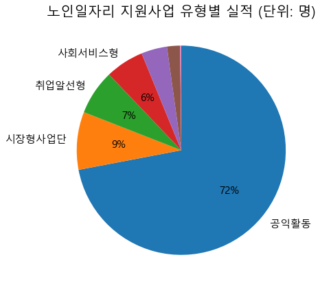

```python
# 그래프로 시각화

x = ['공익활동','시장형사업단','취업알선형','사회서비스형','','','']
y = [554101.0, 68729.0, 53439.0, 45764.0, 30710.0, 15547.0, 1315.0]
# x = ['공익활동','자원봉사활동','사회서비스형','시장형사업단','취업알선형','시니어인턴십','고령자친화기업']
# y = service_df2[0].to_list()[0:7]

# Value 값 5% 미만 텍스트는 출력하지 않는 함수
def custom_autopct(pct):
    return '{:.0f}%'.format(pct) if pct >= 5 else ''

plt.figure(figsize=(7,7))
plt.pie(y, labels=x, autopct=custom_autopct, startangle=90, counterclock=False)  # 값, 라벨, 퍼센트, 시작각도, 시계방향
plt.title('노인일자리 지원사업 유형별 실적 (단위: 명)', fontdict={'fontsize': 20})
plt.show()
```

### ※ 노인일자리 지원사업 일자리 유형

[figure not shown]

출처 - https://blog.naver.com/ikij/222836824872

### [결과 해석]

노인일자리 지원사업 유형 中 **공익활동(72%)** 가장 높음  
**공익활동**이란? 지역사회 공익 증진을 위한 사회참여활동  
월평균 30시간 근무(3시간씩 10일간), 월 27만원 보수

=> 작은 시간을 근무하고, 기초연금보다 적은 금액을 수령

### 3-1. 노인일자리 지원사업 참여 경험

```python
# 조회 sql문 작성
sql="""
select ing, experience, fail, no_apply from senior_job_service_ox
where sort='total';
"""

# sql문 조회 결과 -> DF 생성
experience_df = pd.DataFrame(sql_select(sql)).T
# experience_df
```

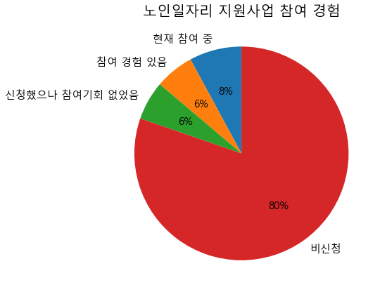

```python
# 그래프로 시각화
x = ['현재 참여 중','참여 경험 있음','신청했으나 참여기회 없었음','비신청']
y = experience_df[0].to_list()

plt.figure(figsize=(7,7))
plt.pie(y, labels=x, autopct=custom_autopct, startangle=90, counterclock=True)  # 값, 라벨, 퍼센트, 시작각도, 시계방향
plt.title('노인일자리 지원사업 참여 경험', fontdict={'fontsize': 20})
plt.show()
```

### [결과 해석]

노인일자리 지원사업 참여 경험은 **비신청(80%)** 가장 높음  
=> 노인일자리 지원사업 **대상자의 범위에 대한 재확인이 필요**하며,  
지원사업 실시에 대한 **다양한 홍보 방법이 필요함**

### 3-2. 노인일자리 지원사업 비신청자 연령별 현황

```python
# 조회 sql문 작성
sql="""
# 연령별 비신청 자료 확인
select ageName, no_apply
from senior_job_service_ox as sjox
	inner join age_sort as as2
	on sjox.sort = as2.sort
where ageName != '전체';
"""

# sql문 조회 결과 -> DF 생성
experience_age_df = pd.DataFrame(sql_select(sql))
experience_age_df
```

|  | 0 | 1 |
| --- | --- | --- |
| 0 | 65세~69세 | 86.6 |
| 1 | 70세~74세 | 79.5 |
| 2 | 75세~79세 | 71.6 |
| 3 | 80세~84세 | 78.4 |
| 4 | 85세 이상 | 85.7 |

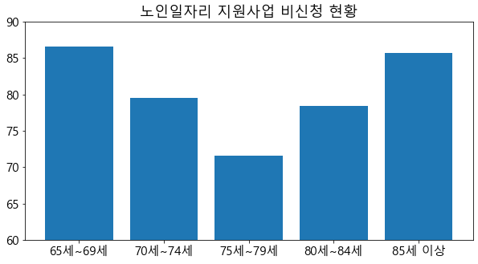

```python
plt.figure(figsize=(10,5))
plt.bar(experience_age_df[0],experience_age_df[1])
plt.title('노인일자리 지원사업 비신청 현황')
plt.ylim(60, 90)
plt.show()
```

### [결과 해석]

노인일자리 지원사업 비신청자들은 **75세~79세(71.6%)가 가장 낮음**

## [결론]

노인일자리 지원사업에 대한 **예산과 실적(일자리수)은 지속적으로 상승**하고 있으나,  
지원사업에 대한 홍보부족 등 상대적으로 **비신청자 비율이 높아 개선이 요구됨**  
또한, 노인일자리 지원사업의 일자리수(양)도 중요하지만,  
**근무시간 및 보수 상승 등 퀄리티(질) 상승도 필요**하다고 사료됨

[출처]

- 한국노인인력개발원 : https://www.kordi.or.kr
- KOSIS 국가통계포털 : https://kosis.kr